# T4 Tail Regression Analysis

Author

Andrea Mariossi

## Experimental Design: T4-Exposure Time-Course

### Overview

**`Overview`**

For each experimental day (replicate_batch), embryos are obtained from a parent set of (5–7 adults). Eggs are pooled and fertilized using a mixed sperm pool from the same parent set. After fertilization, embryos are randomly allocated into dishes assigned to one of six conditions (Control and Cond_1–Cond_5), which represent different T4-exposure durations.

### Replicate Batches and Conditions

- **Number of replicate_batch:** 4 (performed on 4 different days)
- **Conditions per replicate_batch (6 total):** Control, Cond_1, Cond_2, Cond_3, Cond_4, Cond_5
  - Cond_1–Cond_5 correspond to different T4-exposure durations

### Sample Size and Measurements

- **Embryos per dish (approx.):** 30–70
- **Measured n per dish:** varies by dish (e.g., 33, 37, 42, 47, 49, 50, 53, …)
- **Measurement:** tail length
- **Measurement frequency:** each embryo is measured once (one tail-length measurement per individual)

## Setup

```r
rm(list = ls())

# ---- packages ----
suppressPackageStartupMessages({
  library(tidyverse)
  library(readxl)
  library(ggpubr)
  library(knitr)
  library(kableExtra)
  library(ggdist)
  library(gghalves)
  library(ggforce)
  library(rstatix)
  library(lme4)
  library(lmerTest)
  library(emmeans)
  library(performance)
  library(DHARMa)
  library(Cairo)
  library(cowplot)
})
```

## Data Loading

```r
# ---- paths ----
data_dir <- file.path("..", "source_data")
out_dir  <- file.path("..", "output")

# Uncomment for local absolute path:
# data_dir <- "/Users/andrea/Library/CloudStorage/GoogleDrive-andrea.mariossi@gmail.com/My Drive/4.paper_archive/2025_thyroid_pathway_&_metamorphosis/04.SciAdv_rev/source_data/"

SAVE_OUTPUTS <- FALSE
if (!dir.exists(out_dir)) dir.create(out_dir, showWarnings = FALSE, recursive = TRUE)

# helpers
dpath <- function(...) file.path(data_dir, ...)
opath <- function(...) file.path(out_dir, ...)

# ---- dataset ----
data_file <- "9_T4_percentange_tail_regression.xlsx"
stopifnot(file.exists(dpath(data_file)))
```

## Theme & Style

```r
# ---- theme & style ----
custom_theme <- function() {
  theme(
    axis.ticks = element_line(linewidth = 0.5),
    axis.ticks.length = unit(0.09, "cm"),
    legend.key.height = unit(20, "pt"),
    axis.line = element_blank(),
    panel.border = element_rect(colour = "black", fill = NA, linewidth = 1),
    panel.background = element_blank(),
    plot.background = element_blank(),
    panel.grid.major = element_blank(),
    panel.grid.minor = element_blank(),
    legend.background = element_blank(),
    legend.box.background = element_blank(),
    legend.key = element_blank(),
    strip.background = element_blank()
  )
}

theme_set(theme_pubr(base_size = 13, base_family = "Helvetica") + custom_theme())

# ---- condition order ----
cond_levels <- c("Control","Cond_1","Cond_2","Cond_3","Cond_4","Cond_5")

# ---- color palette ----
color_scheme <- c(
  "Control"  = "#999999",
  "Cond_1"   = "#d9f0a3",
  "Cond_2"   = "#addd8e",
  "Cond_3"   = "#78c679",
  "Cond_4"   = "#41ab5d",
  "Cond_5"   = "#238443"
)

# ---- pretty p-values for kable ----
format_pvalues <- function(df) {
  df %>%
    mutate(across(
      any_of(c("p.value", "p.value.x", "p.value.y", "adj.p.value", "p.adj")),
      ~ case_when(
        . < 0.001 ~ format(., scientific = TRUE, digits = 2),
        TRUE ~ as.character(round(., 4))
      )
    ))
}
```

## Data Preprocessing

```r
# ============================================================================
# T4 TAIL REGRESSION ANALYSIS
# Drug-Exposure Time-Course Experiment
# ============================================================================
# EXPERIMENTAL DESIGN:
# - 4 replicate batches (different days, different parent sets)
# - 6 conditions per batch: Control + Cond_1 to Cond_5 (drug exposure times)
# - ~40-60 embryos per dish
# - Unit of replication: DISH (replicate_batch × condition)
# - Total dishes: 24 (4 batches × 6 conditions)
# - Measurement: tail length (% of body) - one per embryo
# ============================================================================

# Replicate Batch 1 (Day 1, adults A):
# ├── Dish 1: Control (n=47 embryos)
# ├── Dish 2: Cond_1 (n=52 embryos)
# ├── Dish 3: Cond_2 (n=49 embryos)
# ├── Dish 4: Cond_3 (n=45 embryos)
# ├── Dish 5: Cond_4 (n=51 embryos)
# └── Dish 6: Cond_5 (n=48 embryos)
#
# Replicate Batch 2 (Day 2, adults B):
# ├── Dish 2_Control    → embryos 1, 2, 3, ...
# ├── Dish 2_Cond_1     → embryos 1, 2, 3, ...
# └── ...
#
# Replicate Batch 3 (Day 3, Parents C)
# └── ...
#
# ReplicateBatch 4 (Day 4, Parents D)
# └── ...
#
# Total: 4 batches × 6 conditions = 24 dishes
```

```r
# ============================================================================
# T4 TAIL REGRESSION ANALYSIS

# ---- load wide ----
T4_tailReg.df <- readxl::read_excel(dpath(data_file))

T4_tailReg.df %>%
  head() %>%
  kable(caption = "T4 tail regression (wide): first 6 rows") %>%
  kable_styling(bootstrap_options = c("striped", "hover"))
```

T4 tail regression (wide): first 6 rows

| Control_rep1 | Control_rep2 | Control_rep3 | Control_rep4 | Cond_1_rep1 | Cond_1_rep2 | Cond_1_rep3 | Cond_1_rep4 | Cond_2_rep1 | Cond_2_rep2 | Cond_2_rep3 | Cond_2_rep4 | Cond_3_rep1 | Cond_3_rep2 | Cond_3_rep3 | Cond_3_rep4 | Cond_4_rep1 | Cond_4_rep2 | Cond_4_rep3 | Cond_4_rep4 | Cond_5_rep1 | Cond_5_rep2 | Cond_5_rep3 | Cond_5_rep4 |
| --- | --- | --- | --- | --- | --- | --- | --- | --- | --- | --- | --- | --- | --- | --- | --- | --- | --- | --- | --- | --- | --- | --- | --- |
| 50 | 40 | 45 | 55 | 80 | 75 | 70 | 80 | 60 | 70 | 65 | 65 | 50 | 45 | 55 | 55 | 60 | 60 | 65 | 60 | 65 | 80 | 65 | 70 |
| 50 | 40 | 50 | 60 | 70 | 90 | 65 | 70 | 65 | 80 | 70 | 75 | 50 | 55 | 60 | 60 | 65 | 60 | 65 | 70 | 70 | 80 | 85 | 60 |
| 55 | 45 | 45 | 60 | 70 | 85 | 70 | 80 | 65 | 65 | 65 | 70 | 50 | 55 | 55 | 50 | 65 | 65 | 55 | 60 | 65 | 90 | 90 | 75 |
| 55 | 50 | 50 | 55 | 70 | 85 | 75 | 65 | 75 | 65 | 75 | 60 | 45 | 45 | 45 | 50 | 65 | 70 | 75 | 80 | 75 | 70 | 80 | 75 |
| 45 | 40 | 50 | 55 | 80 | 80 | 75 | 80 | 75 | 65 | 75 | 70 | 60 | 50 | 50 | 45 | 65 | 75 | 65 | 60 | 65 | 60 | 70 | 65 |
| 50 | 55 | 45 | 45 | 65 | 70 | 75 | 75 | 65 | 75 | 60 | 65 | 55 | 55 | 50 | 60 | 65 | 80 | 65 | 70 | 75 | 80 | 75 | 65 |

```r
# ---- tidy long ----
T4_tailReg_tidy <- T4_tailReg.df %>%
  pivot_longer(
    cols = everything(),
    names_to = c("condition", "replicate_batch"),
    names_pattern = "^(.*)_rep(\\d+)$",
    values_to = "tail_length",
    values_drop_na = TRUE
  ) %>%
  mutate(
    condition = factor(condition, levels = cond_levels),
    replicate_batch = factor(replicate_batch),
    dish_id = interaction(replicate_batch, condition, drop = TRUE)
  )

# quick counts
counts_by_dish <- T4_tailReg_tidy %>%
  count(condition, replicate_batch, name = "n_fish") %>%
  arrange(condition, replicate_batch)
# Summarise by treatment
T4_tailReg_tidy |>
  filter(!is.na(tail_length)) |>
  summarise(n_individuals = n(), .by = condition)
```

```
# A tibble: 6 × 2
  condition n_individuals
  <fct>             <int>
1 Control             184
2 Cond_1              206
3 Cond_2              260
4 Cond_3              258
5 Cond_4              191
6 Cond_5              209
```

```r
# Summarise by replicate_batch
T4_tailReg_tidy |>
  filter(!is.na(tail_length)) |>
  summarise(n_individuals = n(), .by = replicate_batch)
```

```
# A tibble: 4 × 2
  replicate_batch n_individuals
  <fct>                   <int>
1 1                         327
2 2                         329
3 3                         340
4 4                         312
```

```r
# totals embryos counts
T4_tailReg_tidy |>
  filter(!is.na(tail_length)) |>
  count(condition, replicate_batch, name = "n_individuals") |>
  summarise(total_individuals = sum(n_individuals))
```

```
# A tibble: 1 × 1
  total_individuals
              <int>
1              1308
```

```r
counts_by_dish %>%
  kable(caption = "Counts per dish (condition × replicate_batch)") %>%
  kable_styling(bootstrap_options = c("striped", "hover"))
```

Counts per dish (condition × replicate_batch)

| condition | replicate_batch | n_fish |
| --- | --- | --- |
| Control | 1 | 37 |
| Control | 2 | 47 |
| Control | 3 | 67 |
| Control | 4 | 33 |
| Cond_1 | 1 | 53 |
| Cond_1 | 2 | 49 |
| Cond_1 | 3 | 50 |
| Cond_1 | 4 | 54 |
| Cond_2 | 1 | 65 |
| Cond_2 | 2 | 69 |
| Cond_2 | 3 | 66 |
| Cond_2 | 4 | 60 |
| Cond_3 | 1 | 65 |
| Cond_3 | 2 | 68 |
| Cond_3 | 3 | 63 |
| Cond_3 | 4 | 62 |
| Cond_4 | 1 | 53 |
| Cond_4 | 2 | 42 |
| Cond_4 | 3 | 47 |
| Cond_4 | 4 | 49 |
| Cond_5 | 1 | 54 |
| Cond_5 | 2 | 54 |
| Cond_5 | 3 | 47 |
| Cond_5 | 4 | 54 |

```r
cat("\n=== DATA STRUCTURE ===\n")
```

```
=== DATA STRUCTURE ===
```

```r
cat("Total embryo measurements:", nrow(T4_tailReg_tidy), "\n")
```

```
Total embryo measurements: 1308
```

```r
cat("Number of batches:", n_distinct(T4_tailReg_tidy$replicate_batch), "\n")
```

```
Number of batches: 4
```

```r
cat("Number of conditions:", n_distinct(T4_tailReg_tidy$condition), "\n")
```

```
Number of conditions: 6
```

```r
cat("Total dishes:", n_distinct(T4_tailReg_tidy$dish_id), "\n\n")
```

```
Total dishes: 24
```

## QC Data

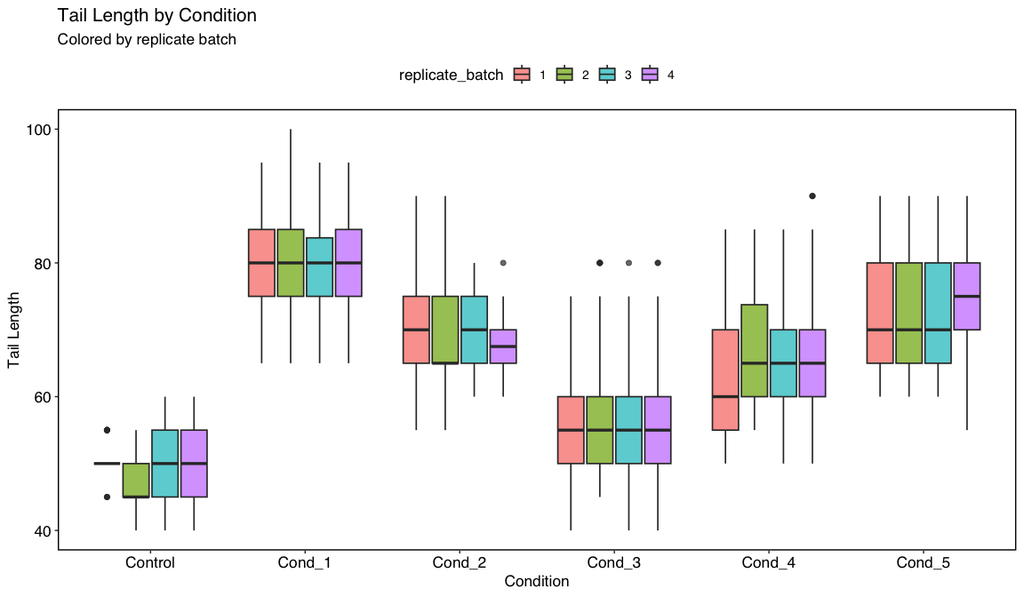

```r
# ---- basic boxplot x replicate ----
ggplot(T4_tailReg_tidy, aes(x = condition, y = tail_length, fill = replicate_batch)) +
  geom_boxplot(alpha = 0.7) +
  labs(title = "Tail Length by Condition",
       subtitle = "Colored by replicate batch",
       x = "Condition",
       y = "Tail Length") +
  custom_theme()
```

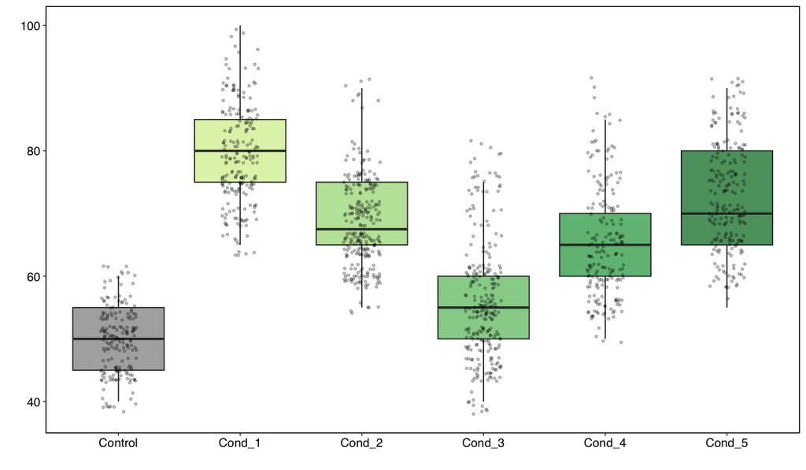

```r
# ---- basic boxplot x condition + jitter ----
ggplot(T4_tailReg_tidy, aes(x = condition, y = tail_length, fill = condition)) +
  geom_boxplot(outlier.shape = NA, alpha = 0.8) +
  geom_jitter(width = 0.15, alpha = 0.25, size = 1) +
  scale_fill_manual(values = color_scheme) +
  labs(x = "", y = "") +
  custom_theme() +
  guides(fill = "none")
```

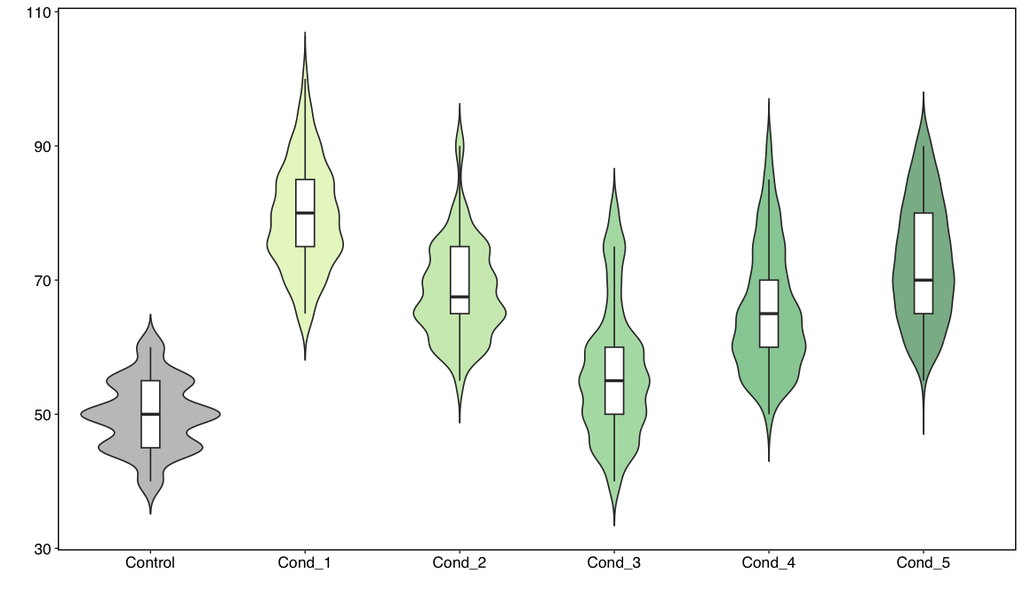

```r
# ---- violin x condition + boxplot ----
ggplot(T4_tailReg_tidy, aes(x = condition, y = tail_length, fill = condition)) +
  geom_violin(trim = FALSE, alpha = 0.6) +
  geom_boxplot(width = 0.12, fill = "white", outlier.shape = NA) +
  scale_fill_manual(values = color_scheme) +
  labs(x = "", y = "") +
  custom_theme() +
  guides(fill = "none")
```

## Statistical Analysis

```r
# ---- sample size summary ----
sample_summary <- T4_tailReg_tidy %>%
  group_by(condition, replicate_batch) %>%
  summarise(n_embryos = n(), .groups = "drop")

sample_summary %>%
  pivot_wider(names_from = replicate_batch, values_from = n_embryos) %>%
  kable(caption = "Embryos per dish") %>%
  kable_styling(bootstrap_options = c("striped", "hover"))
```

Embryos per dish

| condition | 1 | 2 | 3 | 4 |
| --- | --- | --- | --- | --- |
| Control | 37 | 47 | 67 | 33 |
| Cond_1 | 53 | 49 | 50 | 54 |
| Cond_2 | 65 | 69 | 66 | 60 |
| Cond_3 | 65 | 68 | 63 | 62 |
| Cond_4 | 53 | 42 | 47 | 49 |
| Cond_5 | 54 | 54 | 47 | 54 |

```r
condition_totals <- sample_summary %>%
  group_by(condition) %>%
  summarise(total_embryos = sum(n_embryos))

condition_totals %>%
  kable(caption = "Total embryos per condition") %>%
  kable_styling(bootstrap_options = c("striped", "hover"))
```

Total embryos per condition

| condition | total_embryos |
| --- | --- |
| Control | 184 |
| Cond_1 | 206 |
| Cond_2 | 260 |
| Cond_3 | 258 |
| Cond_4 | 191 |
| Cond_5 | 209 |

```r
# ---- aggregate to dish level ----
dish_stats <- T4_tailReg_tidy %>%
  group_by(replicate_batch, condition, dish_id) %>%
  summarise(
    mean_tail = mean(tail_length, na.rm = TRUE),
    sd_tail   = sd(tail_length, na.rm = TRUE),
    n_embryos = n(),
    se_tail   = sd_tail / sqrt(n_embryos),
    .groups = "drop"
  )

dish_stats %>%
  kable(caption = "Dish-level summary (replicate_batch × condition)") %>%
  kable_styling(bootstrap_options = c("striped", "hover"))
```

Dish-level summary (replicate_batch × condition)

| replicate_batch | condition | dish_id | mean_tail | sd_tail | n_embryos | se_tail |
| --- | --- | --- | --- | --- | --- | --- |
| 1 | Control | 1.Control | 50.81081 | 2.767247 | 37 | 0.4549327 |
| 1 | Cond_1 | 1.Cond_1 | 79.71698 | 8.051224 | 53 | 1.1059207 |
| 1 | Cond_2 | 1.Cond_2 | 69.23077 | 8.893061 | 65 | 1.1030485 |
| 1 | Cond_3 | 1.Cond_3 | 55.15385 | 9.268952 | 65 | 1.1496719 |
| 1 | Cond_4 | 1.Cond_4 | 63.86792 | 9.689482 | 53 | 1.3309527 |
| 1 | Cond_5 | 1.Cond_5 | 71.85185 | 8.315494 | 54 | 1.1315955 |
| 2 | Control | 2.Control | 47.65957 | 4.873516 | 47 | 0.7108753 |
| 2 | Cond_1 | 2.Cond_1 | 80.61224 | 8.934522 | 49 | 1.2763603 |
| 2 | Cond_2 | 2.Cond_2 | 68.11594 | 7.769730 | 69 | 0.9353656 |
| 2 | Cond_3 | 2.Cond_3 | 57.50000 | 10.129755 | 68 | 1.2284133 |
| 2 | Cond_4 | 2.Cond_4 | 66.90476 | 7.321234 | 42 | 1.1296909 |
| 2 | Cond_5 | 2.Cond_5 | 72.87037 | 8.332809 | 54 | 1.1339517 |
| 3 | Control | 3.Control | 50.14925 | 5.072964 | 67 | 0.6197612 |
| 3 | Cond_1 | 3.Cond_1 | 78.50000 | 7.160692 | 50 | 1.0126748 |
| 3 | Cond_2 | 3.Cond_2 | 68.48485 | 5.946537 | 66 | 0.7319681 |
| 3 | Cond_3 | 3.Cond_3 | 55.31746 | 9.832181 | 63 | 1.2387384 |
| 3 | Cond_4 | 3.Cond_4 | 64.89362 | 8.307236 | 47 | 1.2117350 |
| 3 | Cond_5 | 3.Cond_5 | 72.12766 | 9.073653 | 47 | 1.3235283 |
| 4 | Control | 4.Control | 51.21212 | 6.617957 | 33 | 1.1520384 |
| 4 | Cond_1 | 4.Cond_1 | 79.07407 | 7.465270 | 54 | 1.0158946 |
| 4 | Cond_2 | 4.Cond_2 | 67.83333 | 5.072915 | 60 | 0.6549105 |
| 4 | Cond_3 | 4.Cond_3 | 56.29032 | 9.578643 | 62 | 1.2164888 |
| 4 | Cond_4 | 4.Cond_4 | 66.02041 | 10.306733 | 49 | 1.4723904 |
| 4 | Cond_5 | 4.Cond_5 | 74.16667 | 8.941635 | 54 | 1.2168024 |

```r
# ---- condition means across batches ----
condition_means <- dish_stats %>%
  group_by(condition) %>%
  summarise(
    mean = mean(mean_tail),
    sd   = sd(mean_tail),
    n_batches = n(),
    se   = sd / sqrt(n_batches),
    ci_lower = mean - qt(0.975, n_batches - 1) * se,
    ci_upper = mean + qt(0.975, n_batches - 1) * se,
    .groups = "drop"
  )

condition_means %>%
  kable(caption = "Condition summary across batches (dish means ± 95% CI)") %>%
  kable_styling(bootstrap_options = c("striped", "hover"))
```

Condition summary across batches (dish means ± 95% CI)

| condition | mean | sd | n_batches | se | ci_lower | ci_upper |
| --- | --- | --- | --- | --- | --- | --- |
| Control | 49.95794 | 1.5936796 | 4 | 0.7968398 | 47.42204 | 52.49384 |
| Cond_1 | 79.47583 | 0.9061355 | 4 | 0.4530678 | 78.03396 | 80.91769 |
| Cond_2 | 68.41622 | 0.6050135 | 4 | 0.3025068 | 67.45351 | 69.37893 |
| Cond_3 | 56.06541 | 1.0799709 | 4 | 0.5399855 | 54.34693 | 57.78388 |
| Cond_4 | 65.42168 | 1.3230034 | 4 | 0.6615017 | 63.31648 | 67.52687 |
| Cond_5 | 72.75414 | 1.0352685 | 4 | 0.5176343 | 71.10679 | 74.40148 |

#### Blocked ANOVA on Dish Means

$$\text{mean_tail}_{bc} = \beta_0 + \beta_c \cdot \text{Condition}_c + \gamma_b \cdot \text{Batch}_b + \epsilon_{bc}$$

Where:

- $\text{mean_tail}_{bc}$ = mean tail length for batch $b$, condition $c$
- $\beta_0$ = intercept (baseline tail length for Control in reference batch)
- $\beta_c$ = fixed effect of condition $c$ (treatment effect, $c \in \{\text{Cond\_1, ..., Cond\_5}\}$)
- $\gamma_b$ = fixed effect of batch $b$ (blocking factor, $b \in \{2, 3, 4\}$)
- $\epsilon_{bc} \sim \mathcal{N}(0, \sigma^2)$ = residual error

Design:

- $b \in \{1, 2, 3, 4\}$ (4 replicate batches: different experiments days)
- $c \in \{\text{Control, Cond\_1, Cond\_2, Cond\_3, Cond\_4, Cond\_5}\}$ (control + 5 T4 windows-exposure conditions)
- $n = 24$ dishes (experimental units: $4 \text{ batches} \times 6 \text{ conditions}$)

```r
# Design: condition = treatment (fixed)
#         replicate_batch = blocking factor (fixed)
# Why: Each batch is a complete independent replicate containing all conditions

# ---- blocked linear model on dish means ----
fit_dish <- lm(mean_tail ~ condition + replicate_batch, data = dish_stats)

# ANOVA table
anova_dish <- anova(fit_dish)
print(anova_dish)
```

```
Analysis of Variance Table

Response: mean_tail
                Df  Sum Sq Mean Sq  F value    Pr(>F)
condition        5 2347.54  469.51 348.8074 5.823e-15 ***
replicate_batch  3    2.96    0.99   0.7319    0.5489
Residuals       15   20.19    1.35
---
Signif. codes:  0 '***' 0.001 '**' 0.01 '*' 0.05 '.' 0.1 ' ' 1
```

```r
# Contrasts: each condition vs Control (BH adjusted)
emm_dish <- emmeans(fit_dish, ~ condition)
contrasts_dish <- contrast(emm_dish, method = "trt.vs.ctrl", ref = "Control") %>%
                  summary(adjust = "BH", infer = TRUE)
contrasts_dish %>%
  as.data.frame() %>%
  format_pvalues() %>%
  kable(caption = "Contrasts vs Control (dish means; BH adjusted)") %>%
  kable_styling(bootstrap_options = c("striped", "hover"))
```

Contrasts vs Control (dish means; BH adjusted)

| contrast | estimate | SE | df | lower.CL | upper.CL | t.ratio | p.value |
| --- | --- | --- | --- | --- | --- | --- | --- |
| Cond_1 - Control | 29.517885 | 0.8203782 | 15 | 27.100466 | 31.935304 | 35.980827 | 2.8e-15 |
| Cond_2 - Control | 18.458283 | 0.8203782 | 15 | 16.040864 | 20.875702 | 22.499725 | 9.5e-13 |
| Cond_3 - Control | 6.107467 | 0.8203782 | 15 | 3.690048 | 8.524886 | 7.444697 | 2.1e-06 |
| Cond_4 - Control | 15.463738 | 0.8203782 | 15 | 13.046319 | 17.881157 | 18.849524 | 9.3e-12 |
| Cond_5 - Control | 22.796197 | 0.8203782 | 15 | 20.378778 | 25.213616 | 27.787425 | 6.4e-14 |

### Model Diagnostics

```r
# Model diagnostics
cat("\n--- Checking Model Assumptions ---\n")
```

```
--- Checking Model Assumptions ---
```

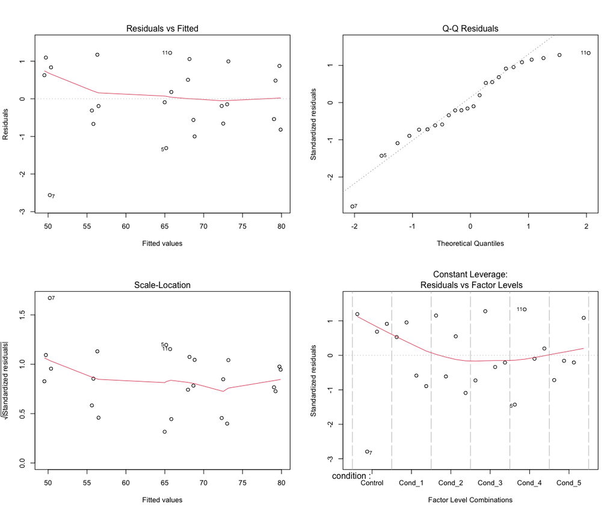

```r
par(mfrow = c(2, 2))
plot(fit_dish)
```

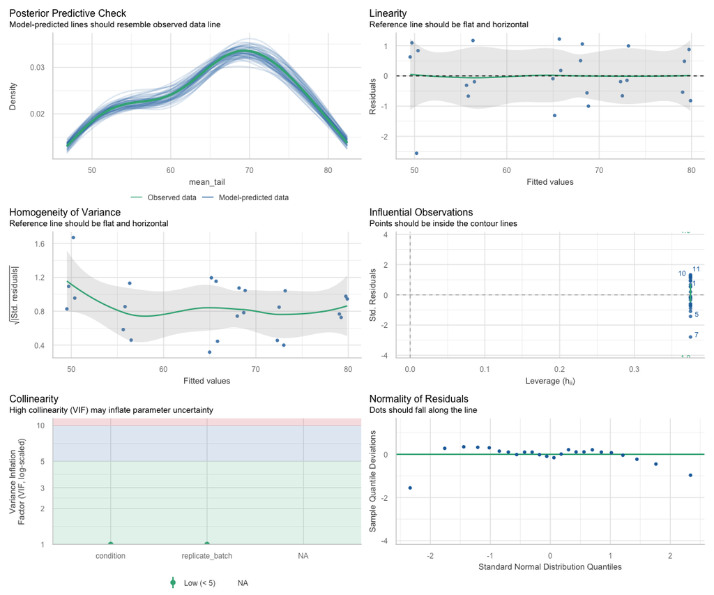

```r
par(mfrow = c(1, 1))
performance::check_model(fit_dish)
```

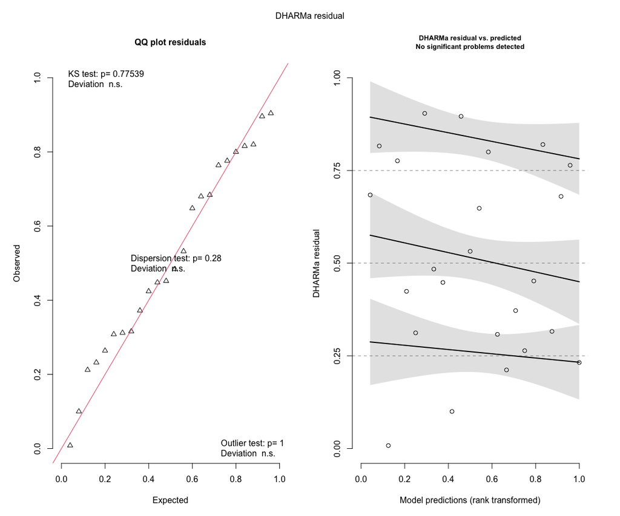

```r
# DHARMa is most informative for mixed models:
sim_res <- DHARMa::simulateResiduals(fit_dish)
plot(sim_res)
```

- **Residuals vs Fitted:** Random scatter (good - no pattern)
- **Q-Q Plot:** Points follow the line well (normality assumption met)
- **Scale-Location:** Relatively flat (homogeneity of variance OK)
- **Residuals vs Factor Levels:** Balanced across conditions (good)

**Results:** F(5,15) = 348.8, p < 0.001 ***

T4 windows exposure duration has a **massive effect** on tail regression.

**Batch effect:** Not significant (F = 0.73, p = 0.55)

| Condition | Mean Difference | 95% CI | Effect |
| --- | --- | --- | --- |
| **Cond_1** | +29.5% | [27.1, 31.9] | Much longer |
| **Cond_2** | +18.5% | [16.0, 20.9] | Longer |
| **Cond_3** | +6.1% | [3.7, 8.5] | Slightly longer |
| **Cond_4** | +15.5% | [13.0, 17.9] | Longer |
| **Cond_5** | +22.8% | [20.4, 25.2] | Much longer |

### Linear Mixed Model with Nested Random Effects

$$\text{tail\_length}_{bcd} = \beta_0 + \beta_c \cdot \text{Condition}_c + u_b + u_{bd} + \epsilon_{bcd}$$

Where:

- $\text{tail\_length}_{bcd}$ = tail length for embryo $d$ in dish within batch $b$, condition $c$
- $\beta_0$ = fixed intercept (overall mean for Control)
- $\beta_c$ = fixed effect of condition $c$ (treatment effect, $c \in \{\text{Cond\_1, ..., Cond\_5}\}$)
- $u_b \sim \mathcal{N}(0, \sigma^2_{\text{batch}})$ = random intercept for batch $b$ (day/parent variation)
- $u_{bd} \sim \mathcal{N}(0, \sigma^2_{\text{dish}})$ = random intercept for dish within batch (dish-level variation)
- $\epsilon_{bcd} \sim \mathcal{N}(0, \sigma^2)$ = residual error (embryo-level variation)

**Random Effects Structure:**

$$(1 | \text{replicate\_batch/dish\_id}) \equiv (1 | \text{replicate\_batch}) + (1 | \text{replicate\_batch:dish\_id})$$

This accounts for:

1. **Batch-level variation** ($\sigma^2_{\text{batch}}$): differences between experimental days/parent sets
2. **Dish-level variation** ($\sigma^2_{\text{dish}}$): differences between dishes within the same batch
3. **Embryo-level variation** ($\sigma^2$): measurement variation between embryos within the same dish

**Variance Partitioning:**

$$\text{Var}(\text{tail\_length}) = \sigma^2_{\text{batch}} + \sigma^2_{\text{dish}} + \sigma^2_{\text{residual}}$$

**Note:** If random effect variances are estimated as zero (singular fit), this indicates minimal variation at those levels, and a simpler blocked ANOVA on dish means may be more appropriate.

```r
# ============================================================================
# Alternative approach: account for dish clustering within the same physical dish
# Batch as a fixed block and Dish as a random effect
# Note: This should give similar results but with more detail on variance components
# ============================================================================

# ---- nested mixed model ----
fit_mixed <- lmer(tail_length ~ condition + (1 | replicate_batch/dish_id),
                  data = T4_tailReg_tidy)

# boundary (singular) fit ==> variation is at the embryo level, treatment effect is SO strong (F = 348) that it overwhelms any dish-to-dish variation. Dishes within the same condition are extremely similar
# That warning means the random‐effect variance for (1 | replicate_batch) is estimated ~0 (i.e., your 4 runs don’t differ much after accounting for condition), or the model can’t reliably estimate it with so few runs.

cat("\n--- Model Summary ---\n")
```

```
--- Model Summary ---
```

```r
print(summary(fit_mixed))
```

```
Linear mixed model fit by REML. t-tests use Satterthwaite's method [
lmerModLmerTest]
Formula: tail_length ~ condition + (1 | replicate_batch/dish_id)
   Data: T4_tailReg_tidy

REML criterion at convergence: 9182.8

Scaled residuals:
     Min       1Q   Median       3Q      Max
-2.18736 -0.65717 -0.04188  0.63535  3.03456

Random effects:
 Groups                  Name        Variance Std.Dev.
 dish_id:replicate_batch (Intercept)  0.00    0.000
 replicate_batch         (Intercept)  0.00    0.000
 Residual                            66.04    8.126
Number of obs: 1308, groups:  dish_id:replicate_batch, 24; replicate_batch, 4

Fixed effects:
                 Estimate Std. Error        df t value Pr(>|t|)
(Intercept)       49.8370     0.5991 1302.0000  83.190  < 2e-16 ***
conditionCond_1   29.6291     0.8243 1302.0000  35.945  < 2e-16 ***
conditionCond_2   18.5861     0.7829 1302.0000  23.741  < 2e-16 ***
conditionCond_3    6.2483     0.7841 1302.0000   7.969 3.48e-15 ***
conditionCond_4   15.5034     0.8394 1302.0000  18.469  < 2e-16 ***
conditionCond_5   22.9382     0.8215 1302.0000  27.922  < 2e-16 ***
---
Signif. codes:  0 '***' 0.001 '**' 0.01 '*' 0.05 '.' 0.1 ' ' 1

Correlation of Fixed Effects:
            (Intr) cndC_1 cndC_2 cndC_3 cndC_4
condtnCnd_1 -0.727
condtnCnd_2 -0.765  0.556
condtnCnd_3 -0.764  0.555  0.585
condtnCnd_4 -0.714  0.519  0.546  0.545
condtnCnd_5 -0.729  0.530  0.558  0.557  0.520
optimizer (nloptwrap) convergence code: 0 (OK)
boundary (singular) fit: see help('isSingular')
```

```r
cat("\n--- ANOVA ---\n")
```

```
--- ANOVA ---
```

```r
print(anova(fit_mixed))
```

```
Type III Analysis of Variance Table with Satterthwaite's method
          Sum Sq Mean Sq NumDF DenDF F value    Pr(>F)
condition 121452   24290     5  1302  367.83 < 2.2e-16 ***
---
Signif. codes:  0 '***' 0.001 '**' 0.01 '*' 0.05 '.' 0.1 ' ' 1
```

```r
cat("\n--- Variance Components ---\n")
```

```
--- Variance Components ---
```

```r
print(VarCorr(fit_mixed))
```

```
 Groups                  Name        Std.Dev.
 dish_id:replicate_batch (Intercept) 0.0000
 replicate_batch         (Intercept) 0.0000
 Residual                            8.1263
```

```r
# Contrasts from mixed model
emm_mixed <- emmeans(fit_mixed, ~ condition)
contrasts_mixed <- summary(
  contrast(emm_mixed, method = "trt.vs.ctrl", ref = "Control"),
  adjust = "BH"
)

contrasts_mixed %>%
  as.data.frame() %>%
  format_pvalues() %>%
  kable(caption = "Contrasts vs Control (fish-level lmer; BH adjusted)") %>%
  kable_styling(bootstrap_options = c("striped", "hover"))
```

Contrasts vs Control (fish-level lmer; BH adjusted)

| contrast | estimate | SE | df | t.ratio | p.value |
| --- | --- | --- | --- | --- | --- |
| Cond_1 - Control | 29.629063 | 0.8315341 | 17.89324 | 35.631809 | 2.3e-17 |
| Cond_2 - Control | 18.586120 | 0.7894571 | 14.47567 | 23.542915 | 7.5e-13 |
| Cond_3 - Control | 6.248315 | 0.7911064 | 14.61842 | 7.898198 | 1.2e-06 |
| Cond_4 - Control | 15.503358 | 0.8470348 | 19.16734 | 18.303095 | 2.2e-13 |
| Cond_5 - Control | 22.938163 | 0.8293729 | 17.66518 | 27.657238 | 1.4e-15 |

### Mixed Model Diagnostics

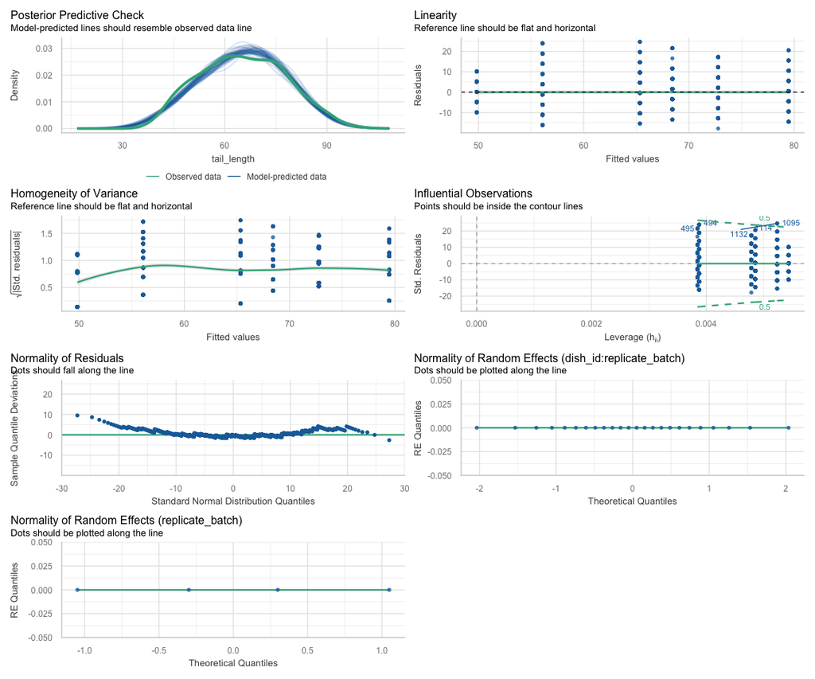

```r
performance::check_model(fit_mixed)
```

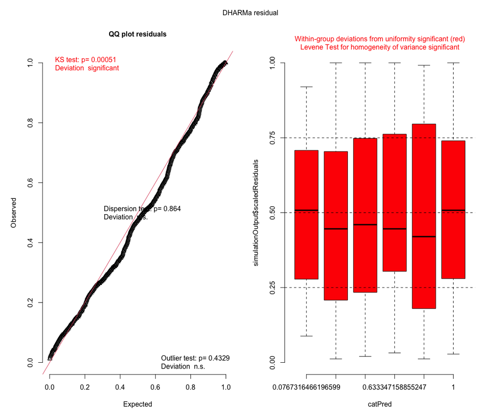

```r
# DHARMa residuals
sim_res <- DHARMa::simulateResiduals(fit_mixed, plot = FALSE)
plot(sim_res)
```

## Visualization

### Dish Means per Batch (Spaghetti Plot)

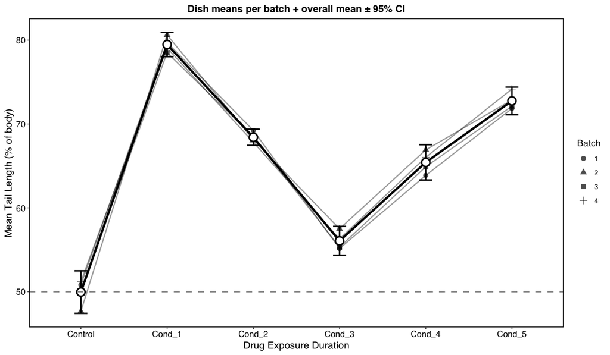

```r
spaghetti_plot <- ggplot() +
  geom_line(
    data = dish_stats,
    aes(x = condition, y = mean_tail, group = replicate_batch),
    alpha = 0.4, linewidth = 0.8
  ) +
  geom_point(
    data = dish_stats,
    aes(x = condition, y = mean_tail, shape = replicate_batch),
    size = 3, alpha = 0.7
  ) +
  geom_errorbar(
    data = condition_means,
    aes(x = condition, ymin = ci_lower, ymax = ci_upper),
    width = 0.15, linewidth = 1
  ) +
  geom_line(
    data = condition_means,
    aes(x = condition, y = mean, group = 1),
    linewidth = 1.5
  ) +
  geom_point(
    data = condition_means,
    aes(x = condition, y = mean),
    size = 4.5, shape = 21, fill = "white", stroke = 1.5
  ) +
  geom_hline(yintercept = 50, linetype = "dashed", color = "#999999", linewidth = 1) +
  labs(
    x = "Drug Exposure Duration",
    y = "Mean Tail Length (% of body)",
    shape = "Batch",
    title = "Dish means per batch + overall mean ± 95% CI"
  ) +
  theme(
    plot.title = element_text(face = "bold", hjust = 0.5, size = 14),
    axis.title = element_text(size = 14),
    axis.text = element_text(size = 12),
    legend.position = "right"
  )

print(spaghetti_plot)
```

```r
line_plot <- ggplot() +
  geom_line(
    data = dish_stats,
    aes(x = condition, y = mean_tail, group = replicate_batch),
    alpha = 0.5
  ) +
  geom_point(
    data = dish_stats,
    aes(x = condition, y = mean_tail),
    size = 2.3,
    alpha = 0.8
  ) +
  geom_errorbar(
    data = condition_means,
    aes(x = condition, ymin = ci_l, ymax = ci_u),
    width = 0.15,
    linewidth = 0.8
  ) +
  geom_line(
    data = condition_means,
    aes(x = condition, y = mean, group = 1),
    linewidth = 1.2
  ) +
  geom_point(
    data = condition_means,
    aes(x = condition, y = mean),
    size = 3.6,
    shape = 21,
    fill = "white",
    stroke = 1
  ) +
  labs(
    x = "Condition (T4 exposure time)",
    y = "Mean tail length (dish mean)",
    title = "Dish means per batch (spaghetti) + overall mean ± 95% CI"
  ) +
  custom_theme() +
  theme(plot.title = element_text(face = "bold", hjust = 0.5))

# Spaghetti plot: dish means per batch + overall mean
spaghetti_plot <- ggplot() +
  # Batch-specific dish means
  geom_line(
    data = dish_stats,
    aes(x = condition, y = mean_tail, group = replicate_batch),
    alpha = 0.4, linewidth = 0.8
  ) +
  geom_point(
    data = dish_stats,
    aes(x = condition, y = mean_tail, shape = replicate_batch),
    size = 3, alpha = 0.7
  ) +
  # Overall mean ± 95% CI
  geom_errorbar(
    data = condition_means,
    aes(x = condition, ymin = ci_lower, ymax = ci_upper),
    width = 0.15, linewidth = 1
  ) +
  geom_line(
    data = condition_means,
    aes(x = condition, y = mean, group = 1),
    linewidth = 1.5
  ) +
  geom_point(
    data = condition_means,
    aes(x = condition, y = mean),
    size = 4.5, shape = 21, fill = "white", stroke = 1.5
  ) +
  geom_hline(yintercept = 50, linetype = "dashed", color = "#999999", linewidth = 1) +
  labs(
    x = "Drug Exposure Duration",
    y = "Mean Tail Length (% of body)",
    shape = "Batch",
    title = "Dish means per batch + overall mean ± 95% CI"
  ) +
  theme(
    plot.title = element_text(face = "bold", hjust = 0.5, size = 14),
    axis.title = element_text(size = 14),
    axis.text = element_text(size = 12),
    legend.position = "right"
  )
```

### Figures 2E: Embryo-Level Distribution (Half-Violin + Sina)

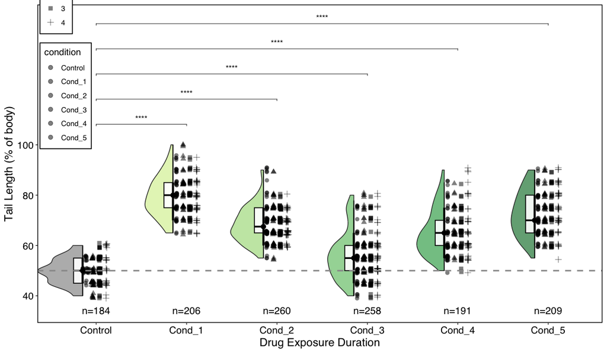

```r
# comparisons
comparisons <- list(
  c("Control", "Cond_1"),
  c("Control", "Cond_2"),
  c("Control", "Cond_3"),
  c("Control", "Cond_4"),
  c("Control", "Cond_5")
)

# n labels
n_labels <- condition_totals %>%
  mutate(
    label = paste0("n=", total_embryos),
    y_pos = 37
  )

tr_plot <- ggplot(T4_tailReg_tidy, aes(x = condition, y = tail_length)) +
  gghalves::geom_half_violin(
    aes(fill = condition),
    side = "l",
    adjust = 1.3,
    alpha = 0.7,
    width = 1,
    show.legend = FALSE,
    position = position_nudge(x = -0.15)
  ) +
  gghalves::geom_half_boxplot(
    side = "l",
    alpha = 0.9,
    width = 0.2,
    fill = "white",
    color = "black",
    errorbar.draw = FALSE,
    show.legend = FALSE,
    outlier.shape = NA,
    position = position_nudge(x = -0.15)
  ) +
  ggforce::geom_sina(
    aes(fill = condition, shape = replicate_batch),
    size = 2.5,
    bin_limit = 1,
    maxwidth = 0.3,
    color = "black",
    alpha = 0.5
  ) +
  ggdist::stat_pointinterval(
    position = position_nudge(x = -0.15),
    show.legend = FALSE
  ) +
  geom_hline(yintercept = 50, linetype = "dashed", color = "#999999", linewidth = 1) +
  scale_fill_manual(values = color_scheme) +
  scale_y_continuous(limits = c(35, 150), breaks = c(40, 60, 80, 100), oob = scales::squish) +
  labs(x = "Drug Exposure Duration", y = "Tail Length (% of body)", shape = "Batch") +
  custom_theme() +
  theme(
    axis.text.x = element_text(size = 14),
    axis.text.y = element_text(size = 14),
    axis.title = element_text(size = 16),
    legend.position = c(0.05, 0.85),
    legend.background = element_rect(fill = "white", color = "black")
  ) +
  geom_text(
    data = n_labels,
    aes(x = condition, y = y_pos, label = label),
    inherit.aes = FALSE,
    size = 5,
    vjust = 1.5
  ) +
  ggpubr::stat_compare_means(
    comparisons = comparisons,
    method = "wilcox.test",
    label = "p.signif",
    hide.ns = FALSE,
    tip.length = 0.01,
    label.y = c(105, 115, 125, 135, 145)
  )

tr_plot
```

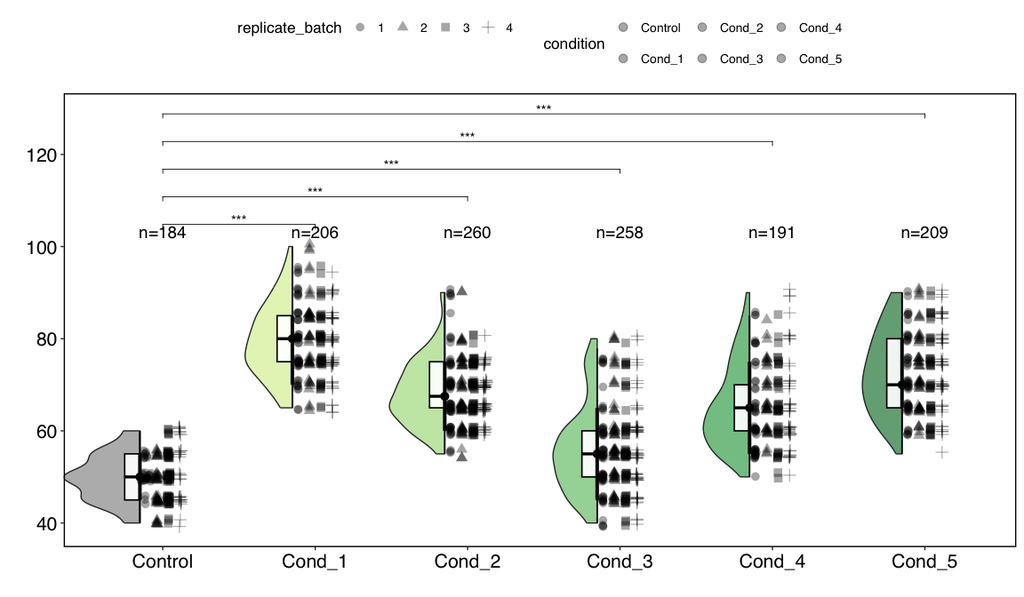

```r
# comparisons (Control vs each Cond)
comparisons <- list(
  c("Control", "Cond_1"),
  c("Control", "Cond_2"),
  c("Control", "Cond_3"),
  c("Control", "Cond_4"),
  c("Control", "Cond_5")
)

# stat test (for brackets; fish-level Wilcoxon as a visual aid)
stat.test <- T4_tailReg_tidy %>%
  rstatix::wilcox_test(tail_length ~ condition, comparisons = comparisons) %>%
  rstatix::adjust_pvalue(method = "BH") %>%
  rstatix::add_significance("p.adj") %>%
  rstatix::add_xy_position(x = "condition")


# n labels (total fish per condition)
n_df <- T4_tailReg_tidy %>%
  count(condition, name = "n_fish") %>%
  mutate(
    label = paste0("n=", n_fish),
    y = max(T4_tailReg_tidy$tail_length, na.rm = TRUE) * 1.02
  )

tr_plot <- ggplot(T4_tailReg_tidy, aes(x = condition, y = tail_length)) +
      # Violin plot

  gghalves::geom_half_violin(
    aes(fill = condition),
    side = "l",
    adjust = 1.3,
    alpha = 0.7,
    width = 1,
    show.legend = FALSE,
    position = position_nudge(x = -0.15)
  ) +
  gghalves::geom_half_boxplot(
    side = "l",
    alpha = 0.9,
    width = 0.2,
    fill = "white",
    color = "black",
    errorbar.draw = FALSE,
    show.legend = FALSE,
    outlier.shape = NA,
    position = position_nudge(x = -0.15)
  ) +
  ggforce::geom_sina(
    aes(fill = condition, shape = replicate_batch),
    size = 3,
    bin_limit = 1,
    maxwidth = 0.3,
    color = "black",
    alpha = 0.35
  ) +
  ggdist::stat_pointinterval(
    position = position_nudge(x = -0.15),
    show.legend = FALSE
  ) +
  scale_fill_manual(values = color_scheme) +
  labs(x = "", y = "") +
  custom_theme() +
  theme(
    axis.text.x = element_text(size = 16),
    axis.text.y = element_text(size = 16)
  ) +
  geom_text(
    data = n_df,
    aes(x = condition, y = y, label = label),
    inherit.aes = FALSE,
    size = 5,
    vjust = 0
  ) +
  ggpubr::stat_pvalue_manual(
    stat.test %>% mutate(p.signif = case_when(
      p.adj < 0.001 ~ "***",
      p.adj < 0.01  ~ "**",
      p.adj < 0.05  ~ "*",
      TRUE ~ "ns"
    )),
    label = "p.signif",
    tip.length = 0.01,
    hide.ns = FALSE
  )

tr_plot
```

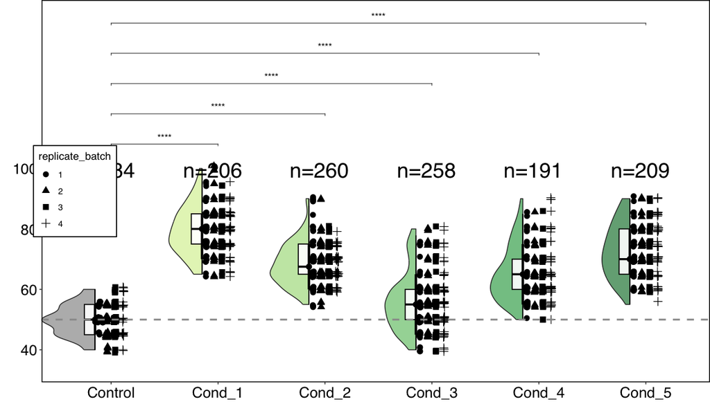

```r
tr_plot2 <- ggplot(T4_tailReg_tidy, aes(x = fct_inorder(condition), y = tail_length)) +
    # Violin plot
    gghalves::geom_half_violin(
      aes(fill = condition),
      side = "l",
      adjust = 1.3,
      alpha = 0.7,
      width = 1,
      show.legend = FALSE,
      position = position_nudge(x = -0.15)
    ) +
    # Boxplot
    gghalves::geom_half_boxplot(
      aes(fill = condition),
      side = "l",
      alpha = 0.9,
      width = 0.2,
      fill = "white",
      color = "black",
      errorbar.draw = FALSE,
      show.legend = FALSE,
      outlier.shape = NA,
      position = position_nudge(x = -0.15)
    ) +
    # Sina plot (individual points)
    ggforce::geom_sina(
      aes(shape = replicate_batch, fill = condition),
      size = 3,
      bin_limit = 1,
      maxwidth = 0.3,
      color = "black"
    # fill = "white"
    # position = position_nudge(x = 0.01)  # Push slightly right
    ) +
    # Point interval
    stat_pointinterval(
      position = position_nudge(x = -0.15),
      show.legend = FALSE
    ) +
    geom_hline(yintercept = 50, linetype = "dashed", color = "#999999", size = 1) +
    # Scales and aesthetics
    scale_y_continuous(limits = c(35, 100), oob = scales::squish) +
    scale_fill_manual(values = color_scheme) +
    labs(x = "", y = "") +
    guides(fill = "none") +
    custom_theme() +
    theme(
      # aspect.ratio = 0.43,
    # coord_fixed(ratio = 0.67 / 2.4),  # Maintain the same height/width ratio
      panel.grid.major.x = element_blank(),
      axis.text.x = element_text(size = 18),
      axis.text.y = element_text(size = 18),
      plot.margin = margin(0, 0, 0, 0, "in"),
      legend.position = c(0.05, 0.5),
      legend.background = element_rect(fill = "white", color = "black"),
      legend.key = element_blank()
    ) +
  geom_text(
    data = n_df,
    aes(x = condition, y = y, label = label),
    inherit.aes = FALSE,
    size = 9,
    vjust = 1,
    position = position_nudge(x = -0.05)  # align with the half-violin/box
  )


tr_plot2 +
  scale_y_continuous(limits = c(35, 150),breaks = c(40, 60, 80, 100),  oob = scales::squish
  ) +
  ggpubr::stat_compare_means(
    comparisons = comparisons,
    method = "wilcox.test",
    label = "p.signif",
    hide.ns = FALSE,
    tip.length = 0.01,
    label.y = c(105, 115, 125, 135, 145)
  )
```

```r
# Create n= labels for plot
n_labels <- condition_totals %>%
  mutate(label = paste0("n=", total_embryos),
         y_pos = 37)

# Main plot: half-violin + boxplot + individual points
main_plot <- ggplot(T4_tailReg_tidy, aes(x = condition, y = tail_length)) +
  # Half violin
  geom_half_violin(
    aes(fill = condition),
    side = "l",
    adjust = 1.3,
    alpha = 0.7,
    width = 1,
    show.legend = FALSE,
    position = position_nudge(x = -0.15)
  ) +
  # Half boxplot
  geom_half_boxplot(
    side = "l",
    alpha = 0.9,
    width = 0.2,
    fill = "white",
    color = "black",
    errorbar.draw = FALSE,
    show.legend = FALSE,
    outlier.shape = NA,
    position = position_nudge(x = -0.15)
  ) +
  # Individual points (colored by batch)
  geom_sina(
    aes(shape = replicate_batch, fill = condition),
    size = 3,
    bin_limit = 1,
    maxwidth = 0.3,
    color = "black"
  ) +
  # Mean + CI
  stat_pointinterval(
    position = position_nudge(x = -0.15),
    show.legend = FALSE
  ) +
  # Reference line at 50%
  geom_hline(yintercept = 50, linetype = "dashed", color = "#999999", linewidth = 1) +
  # Sample size labels
  geom_text(
    data = n_labels,
    aes(x = condition, y = y_pos, label = label),
    inherit.aes = FALSE,
    size = 5,
    vjust = 1,
    position = position_nudge(x = -0.05)
  ) +
  scale_y_continuous(limits = c(35, 100), oob = scales::squish) +
  scale_fill_manual(values = color_scheme) +
  labs(x = "Drug Exposure Duration",
       y = "Tail Length (% of body)",
       shape = "Batch") +
  guides(fill = "none") +
  theme(
    axis.text.x = element_text(size = 14),
    axis.text.y = element_text(size = 14),
    axis.title = element_text(size = 16),
    legend.position = c(0.05, 0.85),
    legend.background = element_rect(fill = "white", color = "black"),
    legend.title = element_text(size = 12),
    legend.text = element_text(size = 10)
  )

# Version with significance brackets
plot_with_sig <- main_plot +
  scale_y_continuous(limits = c(35, 150), breaks = c(40, 60, 80, 100), oob = scales::squish) +
  stat_compare_means(
    comparisons = comparisons,
    method = "wilcox.test",
    label = "p.signif",
    hide.ns = FALSE,
    tip.length = 0.01,
    label.y = c(105, 115, 125, 135, 145)
  )
```

## Save Outputs

```r
if (SAVE_OUTPUTS) {
  # ---- figures ----
  ggsave(opath("T4_tail_distribution.svg"), tr_plot, width = 12, height = 7)
  ggsave(opath("T4_tail_dish_means_spaghetti.svg"), spaghetti_plot, width = 12, height = 7)

  CairoPDF(opath("T4_tail_distribution.pdf"), width = 12, height = 7)
  print(tr_plot)
  dev.off()

  CairoPDF(opath("T4_tail_dish_means_spaghetti.pdf"), width = 12, height = 7)
  print(spaghetti_plot)
  dev.off()

  # ---- tables ----
  readr::write_csv(dish_stats, opath("T4_tail_dish_stats.csv"))
  readr::write_csv(condition_means, opath("T4_tail_condition_means.csv"))
  readr::write_csv(as.data.frame(contrasts_dish), opath("T4_tail_contrasts_vs_control_dish.csv"))
  readr::write_csv(as.data.frame(contrasts_mixed), opath("T4_tail_contrasts_vs_control_fish_lmer.csv"))

  message("\nOutputs saved to: ", out_dir)
}
```